# Tema 09 - Más algoritmos de aprendizaje supervisado

kNN, ‘Naive Bayes’, SVM. Redes Neuronales. ‘Ensemble Learning’ y ‘Boosting’

Pedro Albarrán

Dpto. de Fundamentos del Análisis Económico. Universidad de Alicante

Alberto Pérez

# k-NN (‘k-nearest neighbors’)

## k-NN

- Métodos paramétricos = supuesto funcional para la **esperanza condicional**
  - variable numérica: $E[y|\mathbf{X}=x_0]=f(x_0)=\beta_0+\beta_1 x_0$
  - variable categórica: $\Pr(y=j|\mathbf{X}=x_0) =f_j(x_0)=\Lambda(\beta_{0j}+\beta_{1j} x_0)$
- k-NN estima la esperanza condicional de forma no parámetrica
- Idea: el valor esperado de $y$ para una observación debe ser “similar” al de otras observaciones “cercanas” (por su valor en $\mathbf{X}$)
  - mismo valor de $x_0 \Rightarrow\$ mismo valor esperado de $y$
  - $f(\mathbf{X})\$ no se supone conocida y fija

## Algoritmo k-NN

- Dada una muestra de entrenamiento y una nueva observación $\mathbf{x^*}$
1. Identificar $k>0\quad$ observaciones cercanas según una norma, ej., $||x^*-x_i||_2$
2. Se asigna a $y^*$ la media o la clase mayoritaria de las observaciones cercanas

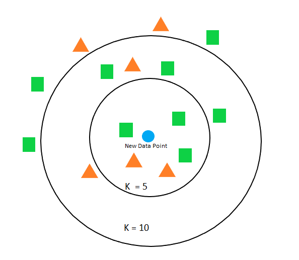

- El valor “óptimo” de $k$ se elige mediante validación cruzada.
  - $k$ bajo (= algoritmo demasiado flexible): alta varianza y sesgo bajo
  - Al aumentar $k$ (menos flexible), menor varianza, pero mayor sesgo

## Algoritmo k-NN: comentarios

- Su utilidad depende de la geometría de los datos
  - conviene centrar y reescalar los datos
  - probar varias medidas de distancia: valor absoluto $|x^*-x_i|\quad$ o norma
- La distancia solo se puede calcular para variables continuas: convertir factores en dummies (una para cada categoría)
- NO es necesario incluir transformaciones no lineales de los regresores (ej., polinomios, interacción, etc.) en la receta
- LASSO (modelo lineal) puede no ser informativo sobre la elección de variables para este algoritmo
- Implementación en R con bibliotecas `class` y `kknn`

# ‘Naive Bayes’

## ‘Naive Bayes’

- En un problema de clasificacón para una variable categórica $y$, tenemos que estimar $\Pr(y=c|\mathbf{x})$
  - Dada una observación nueva $\mathbf{x^*}$, podemos calcular la probabilidad de cada clase
  - Clasificamos esta observación en la clase con mayor probabilidad
- En regresión logística, usamos un modelo paramétrico para la probabilidad $\Pr(y=c|\mathbf{x}) = \Lambda(\beta_0 + \beta_1 \mathbf{x})$
- ¿Y si usamos el Teorema de Bayes?
  $$\Pr(y|\mathbf{x}) = \dfrac{\Pr(y,\mathbf{x})}{\Pr(\mathbf{x})} = \dfrac{\Pr(\mathbf{x}|y)\Pr(y)}{\Pr(\mathbf{x})}$$

## Ejemplo con una sola variable explicativa

- En lo datos de ingresos en el Censo EE.UU., ¿cuál es la probabilidad de ser de renta alta (> 50 mil dólares) si el individuo es blanco?

$$\Pr(>50K|white) = \dfrac{\Pr(white|>50K)\Pr(>50K)}{\Pr(white)}$$

- De los datos obtenemos estas probalidades para predecir en datos nuevos

## ‘Naive Bayes’: caso general

- **Supuesto simplificador** con varias variables explicativas: estas son condicionalmente independientes (poco realista=naive)
  $$\Pr(\mathbf{x}|y)=\prod_{j=1}^p \Pr(x_j|y)$$
- Se puede mejorar la estimación de las probabilidades condicionales $\Pr(x_j|y)$ usando estimadores no-paramétricos de la densidad (“kernels”)
- En `tidymodels` se usa el motor `naivebayes` de la biblioteca `discrim`
- NO necesita preprocesado de los datos salvo que las variables explicativas categóricas deben incluirse como factores
- Tenemos dos hiper-parámetros relacionados con la estimación de la densidad: `smoothness` (suavizado del “kernel”) y corrección de `Laplace`

# ‘Support Vector Machine’ (SVM)

## SVM

- Para un problema de clasificación, SVM encuentra el hiperplano que mejor separa los datos por su clase
- Con dos variables explicativas, se puede visualizar en un gráfico en 2D

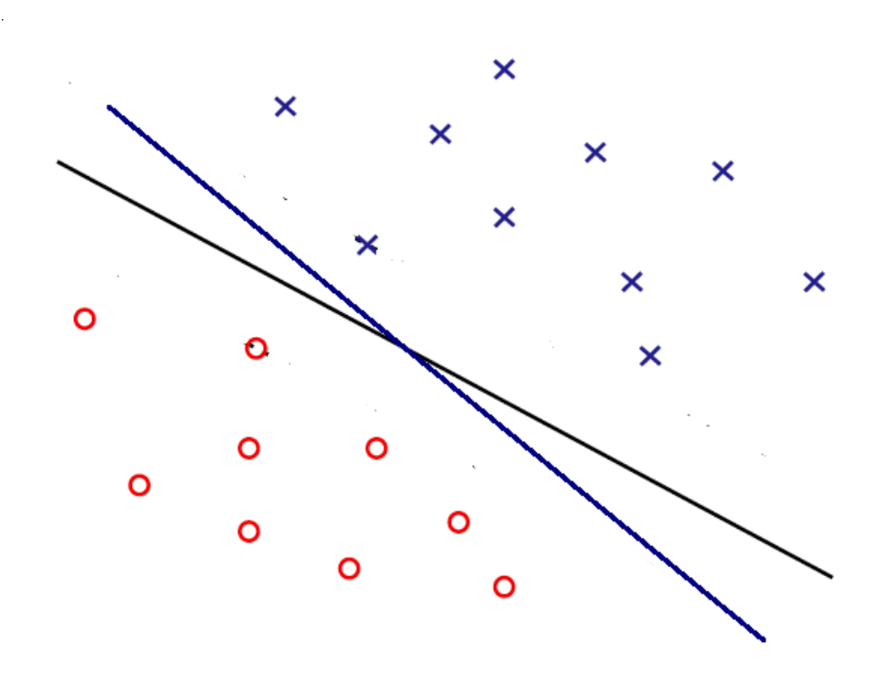

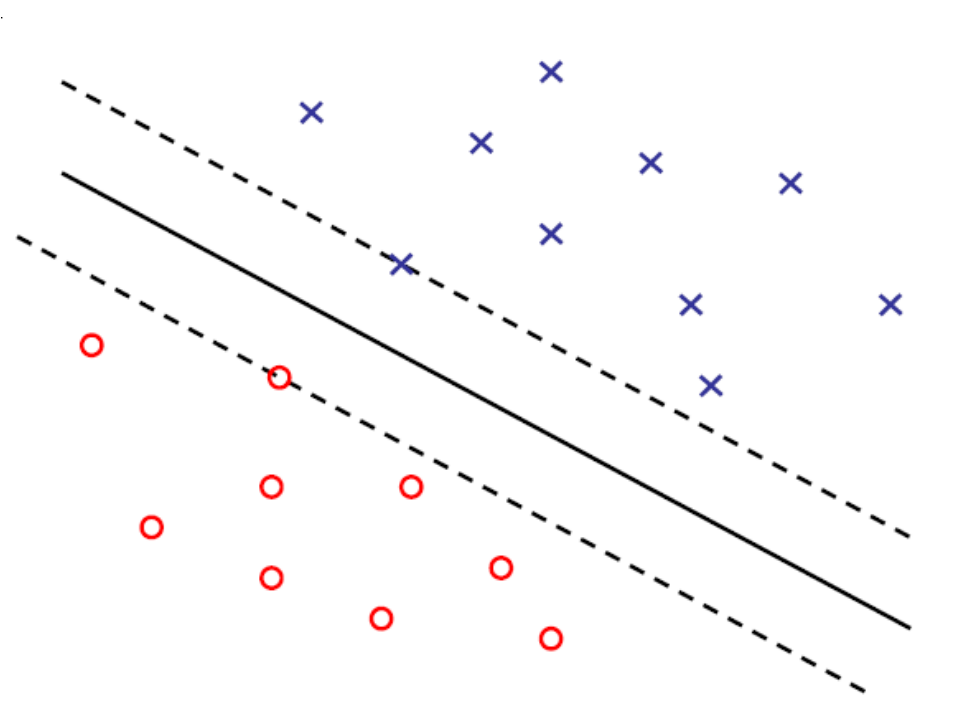

- El hiperplano es una línea cuyos coeficientes debemos encontrar: $\beta_0 + \beta_1 X_1 + \beta_2 X_2 = 0$
- El hiperplano óptimo tiene mayor margen = distancia a los datos más cercanos (llamados vectores de soporte)

## SVM (cont.)

- Los datos no suelen ser linealmente separables: se usa una función $\phi(z)$, denominada kernel, para transformar los datos a un nuevo espacio de mayor dimensión

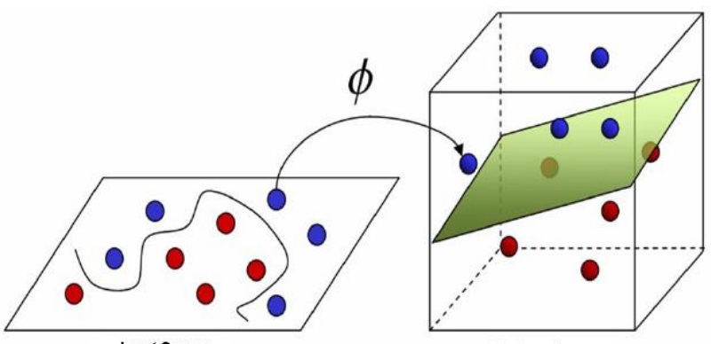

- Para regresión SVM usa el “truco del kernel” para realizar un análisis de regresión lineal en el espacio de mayor dimensionalidad

## SVM (y 3)

- Las variables numéricas deben ser estandarizadas y centradas; las variables categóricas deben ser convertidas a variables dummies
- En `tidymodels` se pueden usar
  - kernels: lineal con `svm_linear()`, radial con `svm_rbf()` y polinomial con `svm_poly()`
  - mediante las bibliotecas `LiblineaR` (solo kernel lineal) y `kernlab`
- Todos tienen un hiperparámetro de coste, `cost`, de predecir en el lado incorrecto del margen
- Existen hiperparámetros adicionales para kernel radial (`rbf_sigma`) y polinomial (`degree`, `scale_factor`)
- En problemas de regresión existe otro hiperparámetro más, `margin`

# Redes Neuronales. “Deep learning”

## Redes Neuronales (artificiales)

- Una red neuronal es una implementación matemática de modelos de estudio del cerebro humano: un grafo dirigido en varias fases.

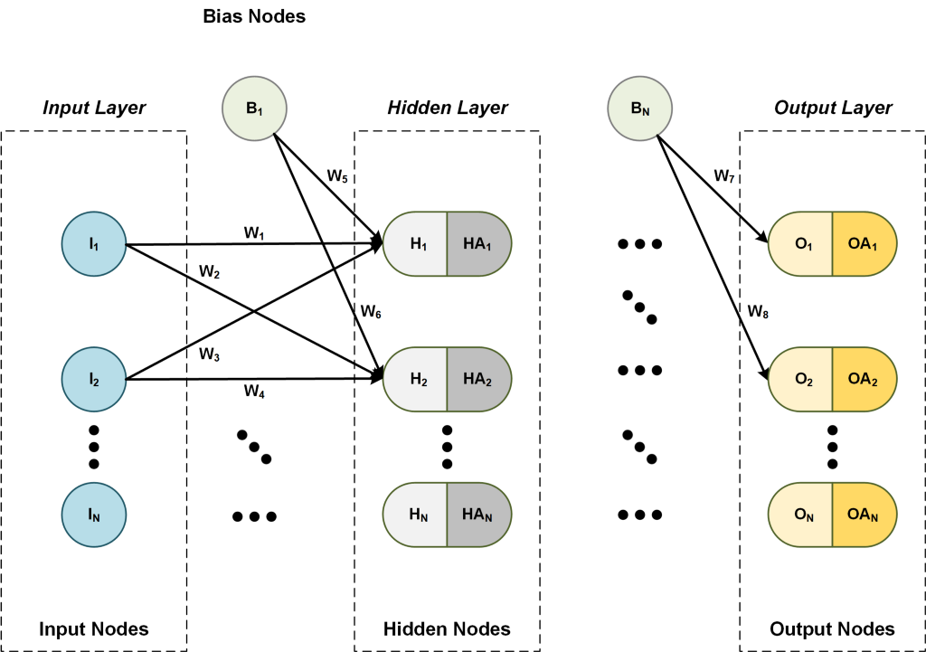

1. Un nodo para cada variable de entrada
2. Nodos especificados como capas ocultas
3. Cada nodo oculto se conecta a nuevas variables de salida
- Dos nodos adicionales de control: uno conectado a los nodos ocultos y otro al de salida

## Redes Neuronales: nodos-percertrones

- En cada nodo oculto se procesa, combinan, agrega la información de los nodos precedentes mediante unos pesos

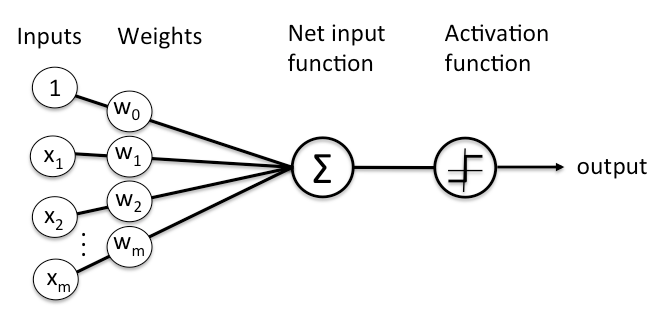

- Esto es “similar” a una regresión logística

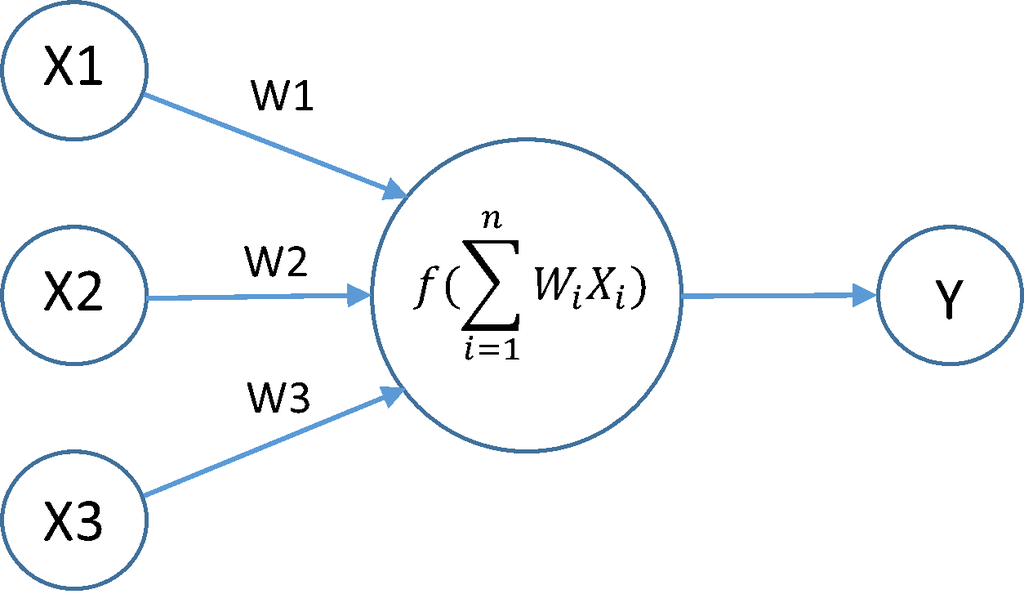

## Redes Neuronales: procedimiento

- El algoritmo busca iterativamente el conjunto óptimo de pesos (“coeficientes”) para cada nodo.
- Entonces, la red neuronal puede hacer predicciones para nuevas entradas ejecutando estos valores a través de la red.

## ‘Deep Learning’

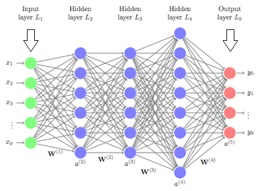

# ‘Ensembling’. ‘Boosting’

## ‘Ensembling’. ‘Boosting’

- Los métodos de *ensembling* (“juntar”) usan varios algoritmos para obtener una mejor predicción que la de cada algoritmo por separado
  - Ya hablamos de *Boostrap aggregation* o *bagging*: es un caso particular de *model averaging*, a su vez un tipo de *ensembling*
  - Otros tipos incluyen: clasificador óptimo bayesiano, *Bayesian model averaging*, *Bayesian model combination*, *bucket of models*, *stacking*, etc.
- *Boosting* es un tipo muy popular de *ensembling* donde cada nuevo modelo se entrena dando más peso a las observaciones que se predijeron peor en el anterior
  - Suele funcionar mejor que *bagging*, pero tiene una mayor tendencia al sobreajuste
  - La implementación más común es *Adaboost* (aunque nueva variantes parecen mejorarlo)